# Session 3

Tim Riffe

8/21/2019

# `if` statements

the command `if` starts it off, then put a condition that evaluates to `TRUE` or `FALSE` in round parentheses, the contain the body of the offset code in curly braces. Either that code gets executed or not, depending on the condition in the round parentheses. Here’s a hypothetical use: Do we use method A or method B? This is predicated on there having been a `method` argument that can have one value or the other.

```r
# la la code entering in here
if (method == "beers"){
  # then execute code that does that
}

if (method == "sprague"){
  # code that does a sprague method
} else {
  print("Sorry I don't have that method")
}
```

Use it to toggle whether to execute code or not. Say you have code that takes a long time to execute and you don’t want to do it repeatedly, but rather only when necessary, and in that case you’ll manually turn it on.

```r
# change this to TRUE if
# we want to run this code
do.this <- FALSE
if (do.this){
HMDLT <- HMD %>%
  group_by(Country, Year, Sex) %>%
  LT_chunk(radix = 100000)
saveRDS(HMDLT, file = here("data","HMDLT.rds"))
}
```

Here’s another example.

```r
x <- rnorm(10)
if (mean(x) > 0){
  print("I'm feeling lucky")
} else {
  print("Today is just not my day")
}
```

```
## [1] "I'm feeling lucky"
```

What happens if ou have more than one `TRUE` / `FALSE`? Then it takes the first one and warns you:

```r
if (x > 0){
  print("I'm feeling lucky")
}
```

```
## Warning in if (x > 0) {: the condition has length > 1 and only the first
## element will be used
```

Here are some ways to do logical checking on vectors.

```r
any(x > 0)
```

```
## [1] TRUE
```

```r
all(x > 0)
```

```
## [1] FALSE
```

```r
all(! (x > 0))
```

```
## [1] FALSE
```

## what about lots of little conditions?

The case of recoding `ifelse()` is vectorized, meaning it’ll do a lot at once without you telling it so explicitly. This works well when the number of cases to deal with is smallish.

```r
edu <- c("sec","pri","ter","ter","sec","pri","pri")
ifelse(edu == "pri", "pri" , ">pri" )
```

```
## [1] ">pri" "pri"  ">pri" ">pri" ">pri" "pri"  "pri"
```

```r
# double-nested
ifelse(edu == "pri", 1,
       ifelse(edu == "sec", 2, 3))
```

```
## [1] 2 1 3 3 2 1 1
```

```r
# mini example of vectorization
a <- rnorm(10)
b <- rnorm(10)
a+b
```

```
##  [1] -0.4368539  1.9089423  2.4443374 -1.1492410 -0.1137667  1.7819258
##  [7]  0.7106643 -1.3348208 -2.1556675  0.4989806
```

But what if there are lots of cases? Do we really need to nest that deep? That’s ugly. Here’s a way around it with `case_when()` from the tidyverse.

```r
library(tidyverse)
x <- 1:50
x -  x %% 5
```

```
##  [1]  0  0  0  0  5  5  5  5  5 10 10 10 10 10 15 15 15 15 15 20 20 20 20
## [24] 20 25 25 25 25 25 30 30 30 30 30 35 35 35 35 35 40 40 40 40 40 45 45
## [47] 45 45 45 50
```

```r
case_when(
  (x %% 5 == 0) & (x %% 7 == 0) ~ "fizzbuzz",
  x %% 5 == 0 ~ "fizz",
  x %% 7 == 0 ~ "buzz",
  TRUE ~ as.character(x)
)
```

```
##  [1] "1"        "2"        "3"        "4"        "fizz"     "6"
##  [7] "buzz"     "8"        "9"        "fizz"     "11"       "12"
## [13] "13"       "buzz"     "fizz"     "16"       "17"       "18"
## [19] "19"       "fizz"     "buzz"     "22"       "23"       "24"
## [25] "fizz"     "26"       "27"       "buzz"     "29"       "fizz"
## [31] "31"       "32"       "33"       "34"       "fizzbuzz" "36"
## [37] "37"       "38"       "39"       "fizz"     "41"       "buzz"
## [43] "43"       "44"       "fizz"     "46"       "47"       "48"
## [49] "buzz"     "fizz"
```

Final case, for when the number of things you need to recode gets really big. Imagine something like reducing 1000 occupational codes to 10, or adding a Continent variable to dataset if you have country codes plus a lookup table. This trick uses named indexing to do its work. It makes sense if there are no `NA`s.

This will also show named indexing.

```r
x <- 1:26
names(x) <- letters

# the values of this vector should be the destination codes.
recode_vector <- sample(1:4, 26, replace = TRUE)

# the names of the vector are the origin codes. Be thorough!
names(recode_vector) <- letters

# you can use the recode_vector like this:
FakeData <- data.frame(ID = sample(letters,
                       100,
                       replace = TRUE))

# Use the column containing the origin codes to
# 'select' from the recode_vector. It expands,
# repeats, and rearranges as required, neat!
FakeData$ID2 <- recode_vector[FakeData$ID]
head(FakeData)
```

```
##   ID ID2
## 1  d   3
## 2  l   2
## 3  q   2
## 4  t   1
## 5  i   4
## 6  t   1
```

Another alternative still would be to just get the two data objects, the main one and the lookup table, and merge them as a data operation. For tips on this (and more `dplyr` functions), look at the `dplyr` cheat sheet.

Logical operators that I can think of right now.

```r
"a" %in% letters
```

```
## [1] TRUE
```

```r
c("a","Z") %in% letters
```

```
## [1]  TRUE FALSE
```

```r
"a" == letters
```

```
##  [1]  TRUE FALSE FALSE FALSE FALSE FALSE FALSE FALSE FALSE FALSE FALSE
## [12] FALSE FALSE FALSE FALSE FALSE FALSE FALSE FALSE FALSE FALSE FALSE
## [23] FALSE FALSE FALSE FALSE
```

```r
c("a","Z") == letters
```

```
##  [1]  TRUE FALSE FALSE FALSE FALSE FALSE FALSE FALSE FALSE FALSE FALSE
## [12] FALSE FALSE FALSE FALSE FALSE FALSE FALSE FALSE FALSE FALSE FALSE
## [23] FALSE FALSE FALSE FALSE
```

```r
x <- rnorm(10)
x >= 0
```

```
##  [1]  TRUE FALSE FALSE  TRUE FALSE FALSE FALSE  TRUE  TRUE  TRUE
```

```r
# ==
# !=
```

# iteration

Well, not iterartion in general, just for-loops for now. Looping is the most general solution to repetetive code execution. It’s done almost the same way in many languages.

```r
for (yr in years){
  # repeat this code
}
```

```r
countries <- c("AUT", "BEL", "DEU", "NLD", "GBR", "USA")
for (cntry in countries){
  print(cntry)
}
```

```
## [1] "AUT"
## [1] "BEL"
## [1] "DEU"
## [1] "NLD"
## [1] "GBR"
## [1] "USA"
```

1. Rule 1, you may or may not actually use the iterator. Here’s a funny example. We increment a counter (for no reason at the moment) to illustrate that the loop repeats once for each element in set that is iterated over.

```r
i <- 0
for (cntry in countries){
  i <- i + 1
  print(i)
}
```

```
## [1] 1
## [1] 2
## [1] 3
## [1] 4
## [1] 5
## [1] 6
```

2. The body knows about objects that were created before the loop. It’s kind of a trivial property, and we point this out because the body of the loop is offset but it is still in your environment at the same level.

```r
A <- 5
B <- 6
for (i in 1:10){
  print(A / i + B * i)
}
```

```
## [1] 11
## [1] 14.5
## [1] 19.66667
## [1] 25.25
## [1] 31
## [1] 36.83333
## [1] 42.71429
## [1] 48.625
## [1] 54.55556
## [1] 60.5
```

You can use loops for trivial things.

```r
x <- rnorm(100)
y <- rnorm(100)
xi <- x * 0
yi <- y * 0
for (i in 1:length(x)){
  xi[i] <- sum(x[1:i])
  yi[i] <- sum(y[1:i])
}
```

In the above we pre-allocated the container for the results, which is best practice. But we don’t need to. We could also grow an object as the loop progresses:

```r
xi <- 0
yi <- 0
for (i in 1:length(x)){
  xi[i] <- sum(x[1:i])
  yi[i] <- sum(y[1:i])
}
# R grows your vector to the required
# size without complaining, dangerously polite
xi[1000] <- 1
```

Many times there is a simple function that already does what we need.

```r
cumsum(x) == xi
```

## Example using the HMD data:

```r
library(here)
library(tidyverse)
source(here("R","Functions.R"))
HMD <- readRDS(here("data","HMD.rds"))

HMDLT <- HMD %>%
  group_by(Country, Year, Sex) %>%
  LT_chunk(radix = 100000)
```

What would this look like in a loop?

```r
countries <- unique(HMD$Country)
sexes     <- unique(HMD$Sex)

HMDLT     <- list()
i         <- 0
for (ctry in countries){
  for (sex in sexes){
    # calculate unique years for
    # this subset without needing
    # to allocate the entire subset
    years <-
      filter(HMD,
             Country == ctry,
             Sex == sex) %>%
      # this is the new function.
      # it extracts a column, kind of
      # like $
      pull(Year) %>%
      unique()
    # This is what we can avoid:
    # chunktoobig <- filter(HMD,
    #          Country == ctry,
    #          Sex == sex)
    # years <- unique(chunktoobig$Year)
    for (yr in years){
      i <- i + 1
      chunk <- filter(HMD,
                      Country == ctry,
                      Sex == sex,
                      Year == yr)
      HMDLT[[i]] <- LT_chunk(chunk,
                             radix = 100000)
    } # end year loop
  } # end sex loop
} # end country loop
HMDLT <- bind_rows(HMDLT)
```

Lesson: don’t grow objects in loops. It’s the memory reallocation stuff under the hood that will slow you down. But there are alternatives.

```r
# make a list, where each element is
# a subset
HMDLT <- split(HMD, list(HMD$Country,
                         HMD$Sex,
                         HMD$Year
                ),
               drop = TRUE)
HMDLT <- lapply(HMDLT,
                LT_chunk,
                radix = 100000)

HMDLT <- bind_rows(HMDLT)
```

But we can borrow a tip from this strategy and not abandon loops altogether:

```r
HMDLT <- split(HMD, list(HMD$Country,
                         HMD$Sex,
                         HMD$Year
                ),
               drop = TRUE)
# for-loop goes here:
# here we iterate down the elements
# of this largish list
for (i in 1:length(HMDLT)){
  HMDLT[[i]] <- LT_chunk(HMDLT[[i]],
                         radix = 100000)
}
HMDLT <- bind_rows(HMDLT)
```

Defensive coding inside this last loop technique:

```r
HMDLT <- split(HMD, list(HMD$Country,
                         HMD$Sex,
                         HMD$Year
                ),
               drop = TRUE)
# for-loop goes here:
# here we iterate down the elements
# of this largish list
for (i in 1:length(HMDLT)){
  if (i == 100){
    HMDLT[[i]]$ax <- as.character(HMDLT[[i]]$ax)
  }
  HMDLT[[i]] <-
    try(LT_chunk(HMDLT[[i]],
                         radix = 100000))
}
HMDLT[[100]] # here's the error message.
# One could also, instead of keeping the message,
# capture some more info and assign that instead.
HMDLT[[101]] %>% head()
# would need to remove the error list elements first.
HMDLT <- bind_rows(HMDLT)
```

# Exercises

1. Start with an integer.
2. 1. if it is even, divide by 2
2. if it is odd, multiply by 3 and add 1
3. wash-wrinse-repeat, count how many steps it takes. That’s the Collatz number.

Step 1, write some lines of code that finds the number. Some correct answers: 1 has a Collatz number of 0. 2 is 1. 3 is 7 (did it on board).

```r
number <- 3
Cnumber <- 0

for (i in 1:1000){
  if (number == 1){
    break
  }
  Cnumber <- Cnumber + 1
  if (number %% 2 == 0){
    number <- number / 2
  } else {
    number <- number * 3 + 1
  }
  number <- as.integer(number)
}
```

Step 2, turn it into a function

```r
Collatz <- function(number, maxit = 1e4){
  Cnumber <- 0
  for (i in 1:maxit){
    number <- as.integer(number)
    if (number == 1){
      return(Cnumber)
    }
    Cnumber <- Cnumber + 1
    if (number %% 2 == 0){
      number <- number / 2
    } else {
      number <- number * 3 + 1
    }
  }
  warning("you better increase maxit!\nNo Cmnumber for you!")
}
```

Step 3, let’s look at the neat pattern-not-pattern

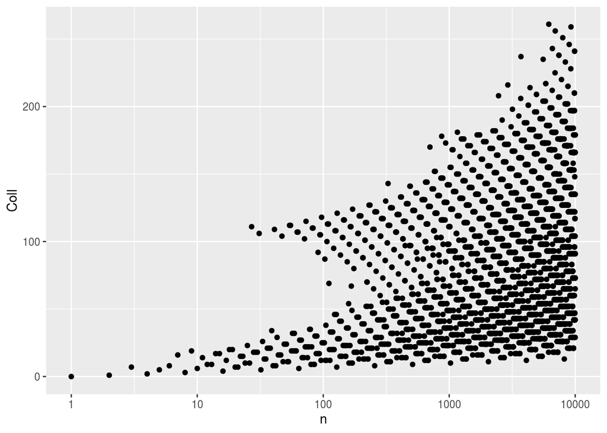

```r
numbers <- 1:10000
Cnumbers <- numbers * 0
for (n in numbers){
  Cnumbers[n] <- Collatz(n)
}
data.frame(n = numbers,
           Coll = Cnumbers) %>%
  ggplot(mapping = aes(x = n,
                       y = Coll)) +
  geom_point() +
  scale_x_log10()
```

## Coale’s iterative method for finding intrinsic $r$

First let’s get a an $L(x)$ vector and an $F(x)$ (ASFR) vector to play with.

```r
HFD <- readRDS(here("data","HFD.rds"))
HMD <- readRDS(here("data","HMD.rds"))
Lx <- HMD %>%
  group_by(Country, Sex, Year) %>%
  LT_chunk(radix = 100000) %>%
  filter(Country == "SWE",Year == 1800,
         Sex == "f") %>%
  pull(Lx)
Lx <- Lx / 100000

Fx <- HFD %>%
  filter(Country == "SWE",Year == 1900) %>%
  pull(ASFR)
Fx <- c(rep(0,11), Fx, rep(0,56)) * .4886 # discount for female births
```

Steps: 1. Calculate $R(0)$ (aka NRR) as:
$$R(0) = \sum L(x) F(x)$$
2. Assume $T$ (mean length of generation in the stable population) is something like 29. 3. calcualte a first guess at $r$
$$r^i = \frac{log(R(0))}{T}$$
4. now in a loop, update `r` in using two steps (i) get a residual
$$\delta = \left(\sum e^{-r^i * x}F(x)*.4886*L(x)\right) - 1$$
(ii) now use $\delta$ to update $r^i$:
$$r^{i+1} = r^i + \frac{\delta}{T - \frac{\delta}{r^i}}$$
5. When $\delta = 0$ you’re done!

And here’s that code!

```r
x     <- .5:110.5
maxit <- 100
tol   <- 1e-10

Coale_r <- function(Fxf, Lx,
                    maxit = 100, tol = 1e-12){
  R0    <- sum(Lx * Fxf) # fixed quantity
  G     <- 29            # assumed
  ri    <- log(R0) / G   # first guess
  for (i in 1:maxit){
    # get residual
    delta <- sum(exp(-ri * x) * Fxf * Lx) - 1
    # use it to adjust r estimate
    ri    <- ri + delta / (G - delta / ri)
    # check for convergence
    if (delta^2 < tol){
      break
    }
  }
  return(ri)
}
# messing around to look for how fert would need to change
# to achieve stationarity.
Coale_r(Fx*1.0252, Lx)
```

```
## [1] 3.01077e-08
```